# Agenda

- Entrance Ticket: [ET_09_18](https://bart.instructure.com/courses/2110/quizzes/3180)
- Slides: stretching and shifting curves
- [OCW_09_17_solve_eq_with_func](https://bart.instructure.com/courses/2110/quizzes/3179)
- [PCW_09_18](https://bart.instructure.com/courses/2110/assignments/28737)

# Problem 1

Curve $y=f[x]$ hits points $(2,0)$ and $(5,6)$ and $(8,4)$.

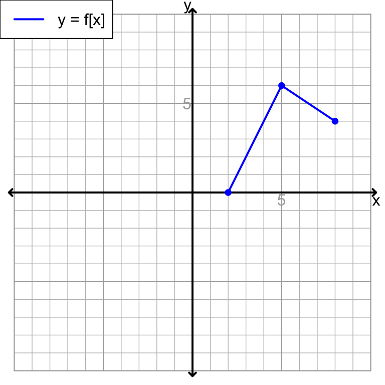

Find the corresponding points of the equation below:

$$y~=~\frac{f[3x-7]}{2}+6$$

# Solution 1

Given equation:

$$y~=~\frac{f[3x-7]}{2}+6$$

We were told three input/output pairs of the function.

$$f[2]=0$$
$$f[5]=6$$
$$f[8]=4$$

Let’s start by using $f[2]=0$, so let’s make the argument equal to $2$.
$$3x-7=2$$
$$3x=9$$
$$x=3$$
$$y=\frac{f[3\cdot 3-7]}{2}+6$$
$$y=\frac{f[9-7]}{2}+6$$
$$y=\frac{f[2]}{2}+6$$
$$y=\frac{0}{2}+6$$
$$y=0+6$$
$$y=6$$
So, the first point on the new curve is $(3,6)$. Now, we can repeat the process using $f[5]=6$.
$$3x-7=5$$
$$3x=12$$
$$x=4$$
$$y=\frac{f[3\cdot 4-7]}{2}+6$$
$$y=\frac{f[12-7]}{2}+6$$
$$y=\frac{f[5]}{2}+6$$
$$y=\frac{6}{2}+6$$
$$y=3+6$$
$$y=9$$
The second point on the new curve is $(4,9)$. Now, we can repeat the process using $f[8]=4$.

$$3x-7=8$$
$$3x=15$$
$$x=5$$
$$y=\frac{f[3\cdot 5-7]}{2}+6$$
$$y=\frac{f[15-7]}{2}+6$$
$$y=\frac{f[8]}{2}+6$$
$$y=\frac{4}{2}+6$$
$$y=2+6$$
$$y=8$$
And, so our last point is at $(5,8)$.

Let’s make a table of the corresponding points:

| point on $y=f(x)$ | point on $y~=~\frac{f[3x-7]}{2}+6$ |
| --- | --- |
| $(2,0)$ | $(3,6)$ |
| $(5,6)$ | $(4,9)$ |
| $(8,4)$ | $(5,8)$ |

- Questions to ponder
  - What formula produces the new $x$ values from the old $x$ values?
  - What formula produces the new $y$ values from the old $y$ values?

Let’s also graph this new curve.

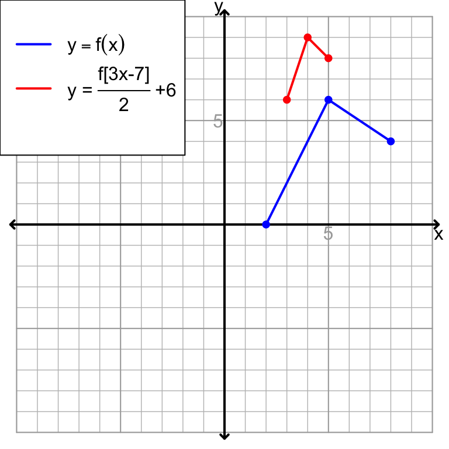

Notice the new curve is half as tall and one third as wide. Also, the new curve has shifted.

# Problem 2

Curve $y=f[x]$ hits points $(-3,5)$ and $(0,0)$ and $(2,4)$.

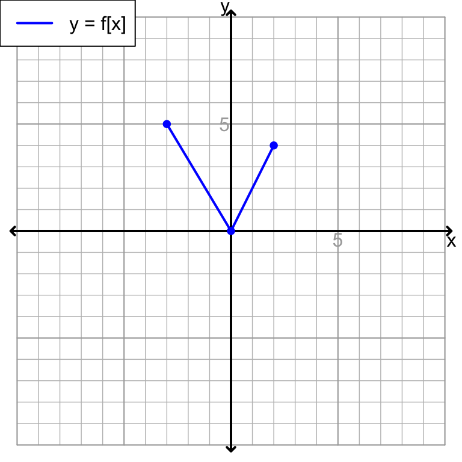

Find the corresponding points of the equation below:

$$y~=~2\cdot
f{\left[\frac{x}{3}-1\right]}-6$$